# Introduction to R.

Macià Salvà Salvà

21746 Data Mining 2022-23

## 1. Data processing

First, Inlude the dataset:

```r
df=read.table(file="auto-mpg.data")
head(df)
```

```
##   V1 V2  V3    V4   V5   V6 V7 V8                        V9
## 1 18  8 307 130.0 3504 12.0 70  1 chevrolet chevelle malibu
## 2 15  8 350 165.0 3693 11.5 70  1         buick skylark 320
## 3 18  8 318 150.0 3436 11.0 70  1        plymouth satellite
## 4 16  8 304 150.0 3433 12.0 70  1             amc rebel sst
## 5 17  8 302 140.0 3449 10.5 70  1               ford torino
## 6 15  8 429 198.0 4341 10.0 70  1          ford galaxie 500
```

The data set vars has no name, we should put name to the columns:

```r
colnames(df)=c("mpg","cylinders","displacement","horsepower","weigth","acceleration","model year","origin","car name")
head(df)
```

```
##   mpg cylinders displacement horsepower weigth acceleration model year origin
## 1  18         8          307      130.0   3504         12.0         70      1
## 2  15         8          350      165.0   3693         11.5         70      1
## 3  18         8          318      150.0   3436         11.0         70      1
## 4  16         8          304      150.0   3433         12.0         70      1
## 5  17         8          302      140.0   3449         10.5         70      1
## 6  15         8          429      198.0   4341         10.0         70      1
##                    car name
## 1 chevrolet chevelle malibu
## 2         buick skylark 320
## 3        plymouth satellite
## 4             amc rebel sst
## 5               ford torino
## 6          ford galaxie 500
```

Look the characteristics of dataset:

```r
str(df)
```

```
## 'data.frame':    398 obs. of  9 variables:
##  $ mpg         : num  18 15 18 16 17 15 14 14 14 15 ...
##  $ cylinders   : int  8 8 8 8 8 8 8 8 8 8 ...
##  $ displacement: num  307 350 318 304 302 429 454 440 455 390 ...
##  $ horsepower  : chr  "130.0" "165.0" "150.0" "150.0" ...
##  $ weigth      : num  3504 3693 3436 3433 3449 ...
##  $ acceleration: num  12 11.5 11 12 10.5 10 9 8.5 10 8.5 ...
##  $ model year  : int  70 70 70 70 70 70 70 70 70 70 ...
##  $ origin      : int  1 1 1 1 1 1 1 1 1 1 ...
##  $ car name    : chr  "chevrolet chevelle malibu" "buick skylark 320" "plymouth satellite" "amc rebel sst" ...
```

In this data frame, the horsepower is “chr” values and it must be double or integer. Also in the dataset, are null values and they must be removed.

```r
df$horsepower <-as.numeric(as.character(df$horsepower))
df=na.omit(df)
str(df)
```

```
## 'data.frame':    392 obs. of  9 variables:
##  $ mpg         : num  18 15 18 16 17 15 14 14 14 15 ...
##  $ cylinders   : int  8 8 8 8 8 8 8 8 8 8 ...
##  $ displacement: num  307 350 318 304 302 429 454 440 455 390 ...
##  $ horsepower  : num  130 165 150 150 140 198 220 215 225 190 ...
##  $ weigth      : num  3504 3693 3436 3433 3449 ...
##  $ acceleration: num  12 11.5 11 12 10.5 10 9 8.5 10 8.5 ...
##  $ model year  : int  70 70 70 70 70 70 70 70 70 70 ...
##  $ origin      : int  1 1 1 1 1 1 1 1 1 1 ...
##  $ car name    : chr  "chevrolet chevelle malibu" "buick skylark 320" "plymouth satellite" "amc rebel sst" ...
##  - attr(*, "na.action")= 'omit' Named int [1:6] 33 127 331 337 355 375
##   ..- attr(*, "names")= chr [1:6] "33" "127" "331" "337" ...
```

Let’s print a summary of our data:

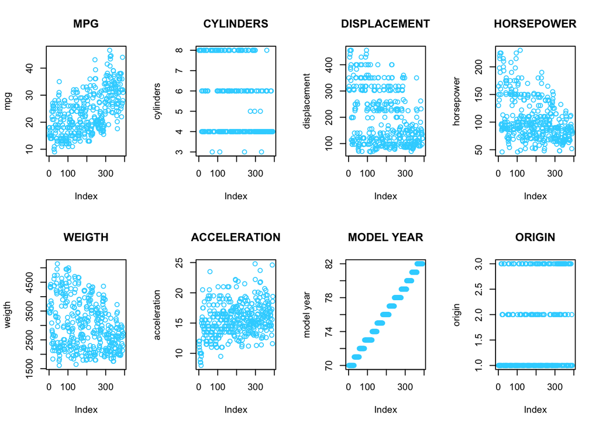

```r
name=colnames(df)
par(mfrow = c(2, 4))
for(i in 1:length(name)) {
  if(i!=length(name)){
    plot(df[, name[i]], main=toupper(name[i]), ylab=name[i],col="#33D4FF")
  }
}
```

We can see that cylinders 3 and 5 are not good data. We have very few examples. Let’s see what examples we have.

```r
#This function print the sum of cylinders examples
printSumCylinders <- function() {
  v <- c(sum(df$cylinders=="3"),sum(df$cylinders=="4"),sum(df$cylinders=="5"),sum(df$cylinders=="8"))

  n <- c("3","4", "5", "8")
  m <- data.frame("Cylynders"=n,"Valores"=v)
  print(m)
}
```

```r
printSumCylinders()
```

```
##   Cylynders Valores
## 1         3       4
## 2         4     199
## 3         5       3
## 4         8     103
```

We can depreciate the valors of cylinders 3 and 5, because are not good examples. Also between 4 and 8 cylinders is not the best data because we have the double on 4 Cylinders with respect to the 8 cylinders.

```r
df=df[df$cylinders!=3, ]
df=df[df$cylinders!=5, ]

printSumCylinders()
```

```
##   Cylynders Valores
## 1         3       0
## 2         4     199
## 3         5       0
## 4         8     103
```

```r
head(df)
```

```
##   mpg cylinders displacement horsepower weigth acceleration model year origin
## 1  18         8          307        130   3504         12.0         70      1
## 2  15         8          350        165   3693         11.5         70      1
## 3  18         8          318        150   3436         11.0         70      1
## 4  16         8          304        150   3433         12.0         70      1
## 5  17         8          302        140   3449         10.5         70      1
## 6  15         8          429        198   4341         10.0         70      1
##                    car name
## 1 chevrolet chevelle malibu
## 2         buick skylark 320
## 3        plymouth satellite
## 4             amc rebel sst
## 5               ford torino
## 6          ford galaxie 500
```

## 2. Questions

### 2.1 What is the relation between Horsepower and the cylinders?

A priori, we think that more cylinders in a car are equivalent to say, this car has more power. Let’s make a graph between these two variables.

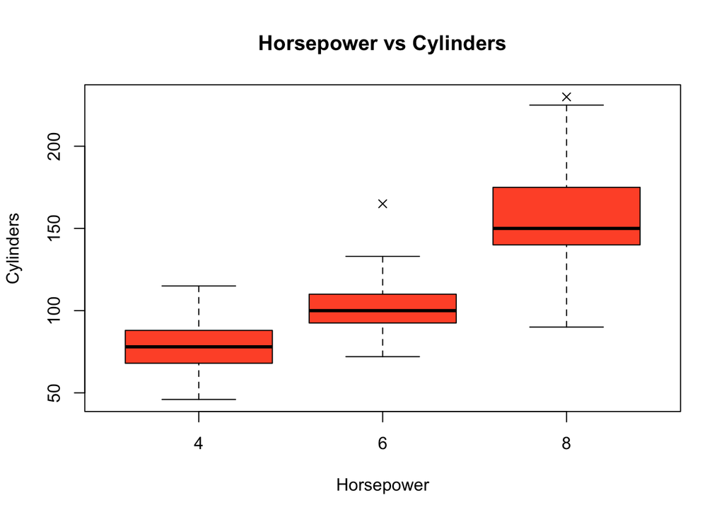

```r
boxplot(df$horsepower~df$cylinders, pch=4,main="Horsepower vs Cylinders", xlab="Horsepower", ylab="Cylinders", col='#FF5733')
```

We can see that it is true because is logical when we have more horsepower have more cylinders.

```r
aggregate(horsepower~cylinders,df,mean)
```

```
##   cylinders horsepower
## 1         4   78.28141
## 2         6  101.50602
## 3         8  158.30097
```

```r
cy=df$cylinders
hp=df$horsepower
cov(df$cylinders,df$horsepower)
```

```
## [1] 56.13451
```

### 2.2 The trend of each year is to have cars with more power?

This could be an interesting question to ask. But, with these data set can really answer that? Do people normally have sports cars? Definitely not.

But let’s see what can be found in the data set. For this question, we decide that if a car has more than 120 horsepower is a power car.

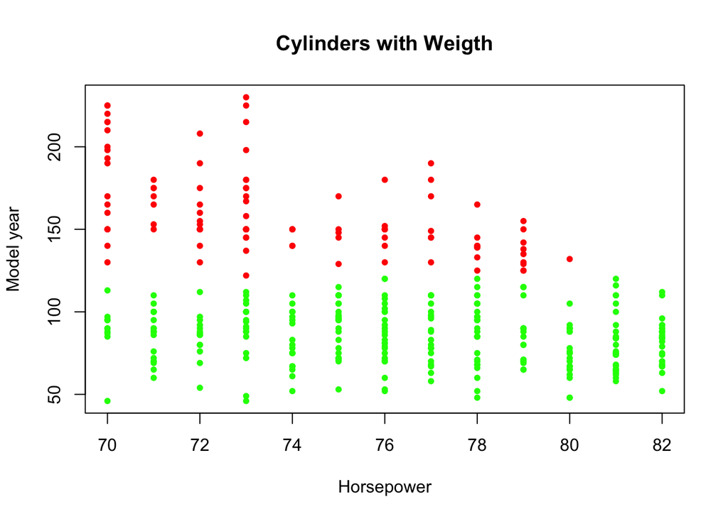

```r
plot(df$`model year`,df$horsepower, main="Cylinders with Weigth", xlab="Horsepower", ylab="Model year",pch=20, col= ifelse(df$horsepower > 120, 'red','green'))
```

With these data this question cannot be solved. We also do not take into account hybrid cars and electric cars. Furthermore we are looking at older cars.

### 2.3 Which cylenders has the better MPG ratio?

I think that if we have more cylinders, we will have less relation MPG. Because we have seen that, if we have more cylinders, we have more power. That power will need more gallons and will produce less relation between MPG.

In these page, we can learn more about MPG: https://reviews.tn/es/wiki/what-is-a-bad-mpg/

Now we will consider:

- If MPG > 35 good relation.
- If 25 < MPG < 35 is not the best relation.
- If MPG < 25 is a bad relation.

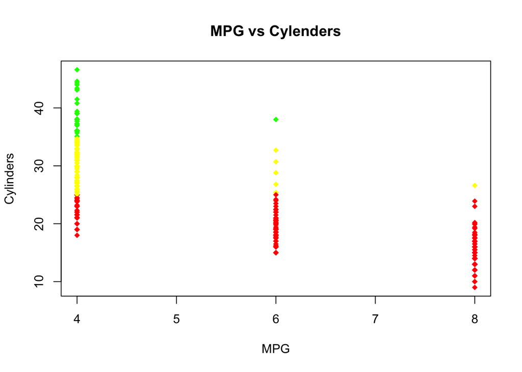

```r
plot(df$cylinders,df$mpg,pch=18,main="MPG vs Cylenders", xlab="MPG", ylab="Cylinders", col = ifelse(df$mpg >35,'green',ifelse(df$mpg >25,'yellow','red')))
```

Now, we can see that the 4 cylinders have the best MPG ratio. It is obvious because they are the least powerful cars in our data set.

### 2.4 What is the relation between the displacement and the cylenders?

Of course. If we search the formula of de displacemnet (https://es.wikipedia.org/wiki/Cilindrada#:~:text=Cilindrada%20es%20la%20denominaci%C3%B3n%20que,equivalen%20a%20una%20pulgada%20c%C3%BAbica.), if we have more cylinders, we will have more displacement.

Formula:
$$UnitDisplacement = \frac{\Pi *
D^{2}}4 * L$$
$$TotalDisplacement =
\frac{\Pi * D^{2}}4 * L *n$$

Where :

- D is the diameter of the cylinder.
- L is the longitud of the piston.
- n totals of the cylinders.

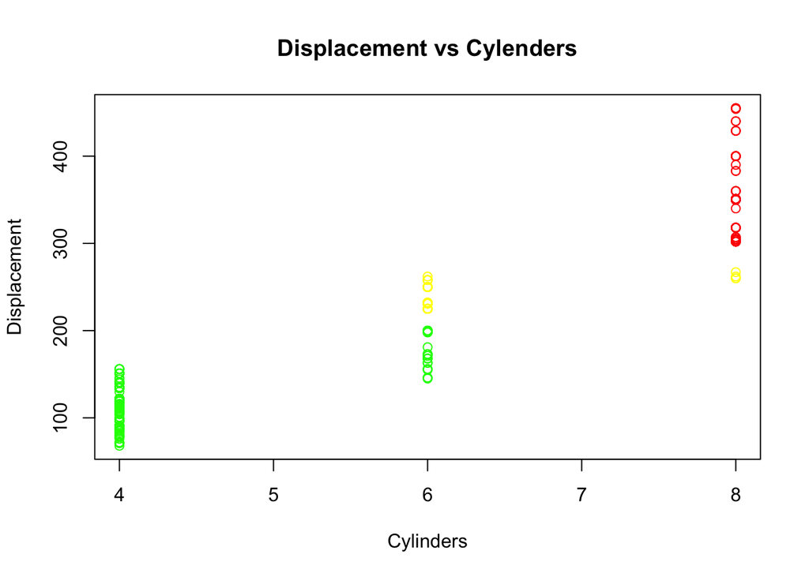

```r
plot(df$cylinders,df$displacement,main="Displacement vs Cylenders", xlab="Cylinders", ylab="Displacement",col = ifelse(df$displacement >300,'red',ifelse(df$displacement >200,'yellow','green')))
```

The red colors are the cars with the largest displacement, while the green colors are the cars with the smallest displacement.

We can see the covariance that good.

```r
cov(df$displacement,df$cylinders)
```

```
## [1] 169.4459
```

It is logic see this relation, also we have deduce it on the intro of these question, and we can see this dependence on the formula

### 2.5 The more cylinders a car has, the heavier it tends to weigth?

All the vehicles that are in this data set are street vehicles. The vehicles of competition have more cylinders and their weight is its weight is very small.

But in the street, the more powerful vehicles have bigger engines. This affects the overall weight of the vehicle.

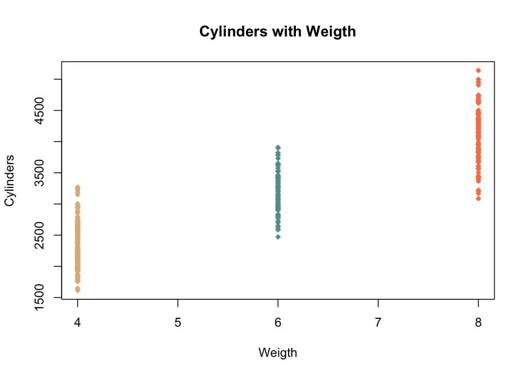

```r
plot(df$cylinders,df$weigth,main="Cylinders with Weigth", xlab="Weigth", ylab="Cylinders", pch=18,col= ifelse(df$cylinders==4,'#DEB887',ifelse(df$cylinders==6,'#5F9EA0','#FF7F50')))
```

We can see a relation between weight and the cylinders. When more cylinders have the car, more weight is it.

## 3. Data Distribution

With a corrplot we can see the dependencies of our variables.

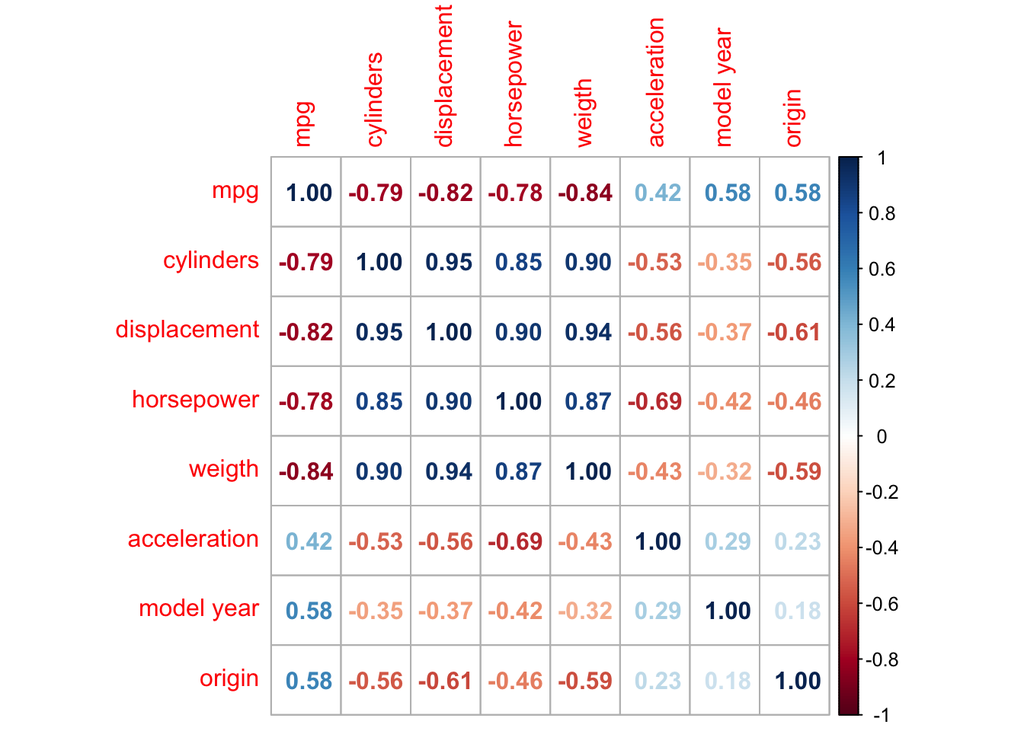

```r
library(corrplot)
corrplot(cor(df[1:8]),method= "number") # colorful number
```

Some of the questions answered, we can see their relationships by means of this matrix. For example between the MPG and the cylinders variable we found a -0.79 is close to 1, that means that there is a relation between these variables.

Also, we can see some variables that not have connexions between them. For example, the ‘Model year’ variable between ‘acceleration’ variable the relationship is not close. But it is logical since they have nothing to do with each other. In a year, cars can been created with higher and lower acceleration.

Let’s see the distribution:

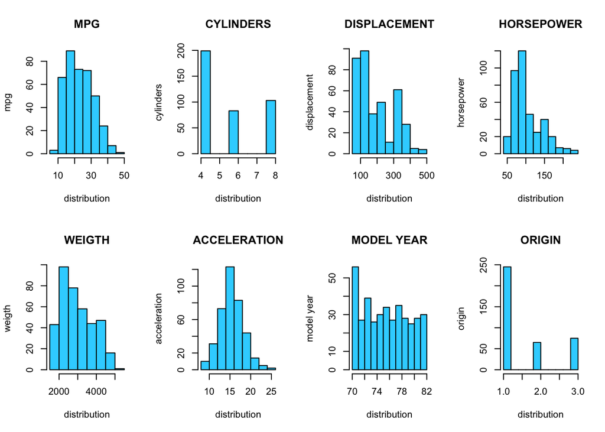

```r
name=colnames(df)
par(mfrow = c(2, 4))
for(i in 1:length(name)) {
  if(i!=length(name)){
    hist(df[, name[i]], main=toupper(name[i]),ylab=name[i],xlab = "distribution",col="#33D4FF")
  }
}
```